# Prior distributions and uncertainty

Peter Ralph

8 January 2018 – Advanced Biological Statistics

## Today

0. Course structure and introductions
   - short survey
1. Probability: review and notation
2. Bayesian analysis
3. Application: Beta distributed coins

# Biased coins

## a motivating example

Suppose I have two trick coins:

- one (coin A) comes up heads 75% of the time, and
- the other (coin B) only 25% of the time.

But, I lost one and I don’t know which! So, I flip it **10 times** and get **6 heads**. *Which is it, and how sure are you?*

## Possible answers:

1. Er, probably coin #1?
2. Well,
   $$\begin{aligned}
   \P\{ \text{6 H in 10 flips} \given \text{coin A} \}
   &= \binom{10}{6} (.75)^6 (.25)^4 \\
   &= 0.146
   \end{aligned}$$
   and
   $$\begin{aligned}
   \P\{ \text{6 H in 10 flips} \given \text{coin B} \}
   &= \binom{10}{6} (.25)^6 (.75)^4 \\
   &= 0.016
   \end{aligned}$$
   … so, probably coin A?

For a precise answer…

3. *Before flipping*, each coin seems equally likely. Then

   $$\begin{aligned}
   \P\{ \text{coin A} \given \text{6 H in 10 flips} \}
   &= \frac{
   \frac{1}{2} \times 0.146
   }{
   \frac{1}{2} \times 0.146
   +
   \frac{1}{2} \times 0.016
   } \\
   &= 0.9
   \end{aligned}$$

# Probability: review and notation

## Probability rules:

0. *Probabilities are proportions:* $\hspace{2em} 0 \le \P\{A\} \le 1$
1. *Everything:* $\hspace{2em} \P\{ \Omega \} = 1$
2. *Complements:* $\hspace{2em} \P\{ \text{not } A\} = 1 - \P\{A\}$
3. *Disjoint events:* If $\hspace{2em} \P\{A \text{ and } B\} = 0$ then $\hspace{2em} \P\{A \text{ or } B\} = \P\{A\} + \P\{B\}$.
4. *Independence:* $A$ and $B$ are independent iff $\P\{A \text{ and } B\} = \P\{A\} \P\{B\}$.
5. *Conditional probability:*
   $$\P\{A \given B\} = \frac{\P\{A \text{ and } B\}}{ \P\{B\} }$$

## Bayes’ rule

A consequence is

$$\P\{B \given A\} = \frac{\P\{B\} \P\{A \given B\}}{ \P\{A\} } .$$

In “Bayesian statistics”:

- $B$: possible model
- $A$: data
- $\P\{B\}$: prior weight on model $B$
- $\P\{A \given B\}$: likelihood of data under $B$
- $\P\{B\} \P\{A \given B\}$: posterior weight on $B$
- $\P\{A\}$: total sum of posterior weights

# Group problem

## More coins

Suppose instead I had 9 coins, with probabilities 10%, 20%, …, 80%, 90%; as before I flipped on 10 times and got 6 heads. For each $\theta$ in $0.1, 0.2, \ldots, 0.8, 0.9$, find
$$\begin{aligned}
\P\{\text{ coin has prob $\theta$ } \given \text{ 6 H in 10 flips } \}
\end{aligned}$$
and plot these as a bar plot.

*Question:* which coin(s) is it, and how sure are you? (and, what do you mean when you say how sure you are)

*Time allowing,* do it again with 99 coins. And 999 coins. Does your answer change?

# Breaking it down

## Uniform prior

prior

$\times$

likelihood

$\propto$

posterior

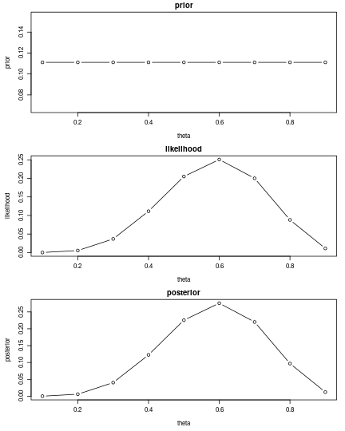

## Weak prior

prior

$\times$

likelihood

$\propto$

posterior

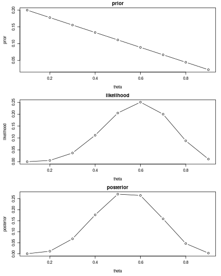

## Strong prior

prior

$\times$

likelihood

$\propto$

posterior

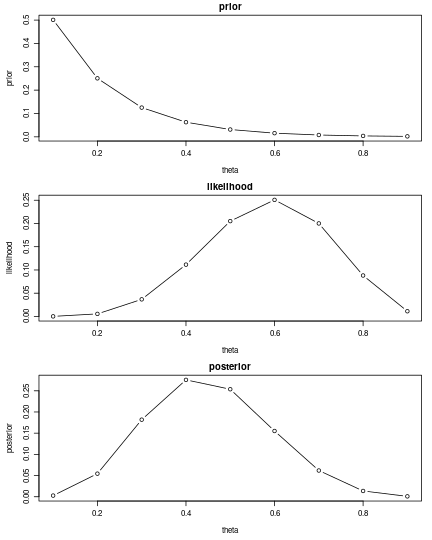

## The likelihod: 6 H in 10 flips

prior

$\times$

likelihood

$\propto$

posterior

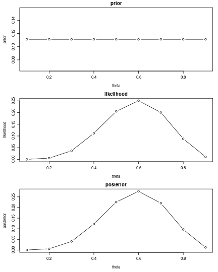

## The likelihod: 30 H in 50 flips

prior

$\times$

likelihood

$\propto$

posterior

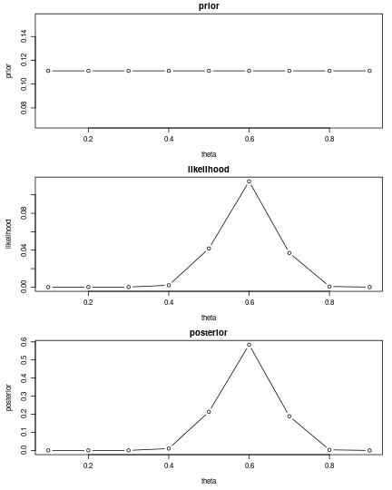

## The likelihod: 60 H in 100 flips

prior

$\times$

likelihood

$\propto$

posterior

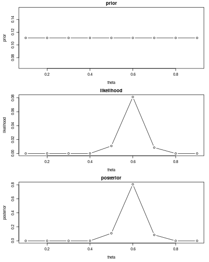

## The likelihod: 6,000 H in 10,000 flips

prior

$\times$

likelihood

$\propto$

posterior

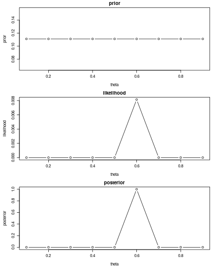

# Stochastic Minute

## The Beta Distribution

If
$$P \sim \text{Beta}(a,b)$$
then $P$ has *probability density*
$$p(\theta) = \frac{ \theta^{a-1} (1 - \theta)^{b-1} }{ B(a,b) } .$$

- Takes values between 0 and 1.
- If $U_{(1)} < U_{(2)} < \cdots < U_{(n)}$ are sorted, independent $\text{Unif}[0,1]$ then $U_{(k)} \sim \text{Beta}(k, n-k+1)$.
- Mean: $a/(a+b)$.
- Larger $a+b$ is more tightly concentrated (like $1/\sqrt{a+b}$)

# ((Thursday))

## Today

0. A look at the homework
1. What’s the question? (and how do we answer it?)
2. Beta-binomial coins.
3. Simulation exercise.
4. Online analysis example.
5. Reporting uncertainty.
6. Normal approximation

# A question

## What is the right answer to the “coin question”?

Recall: there were nine possible values of $\theta$.

Which coin is it, and how sure are you?

*Possible types of answer:*

1. “best guess”
2. “range of values”
3. “don’t know”

Give examples of when each type of answer is the right one.

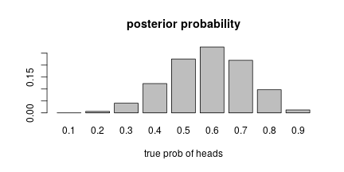

```r
theta <- (1:9)/10
prior <- rep(1/9, 9)
likelihood <- dbinom(6, size=10, prob=theta)
posterior <- prior*likelihood/sum(prior*likelihood)
names(posterior) <- theta
barplot(posterior, xlab='true prob of heads', main='posterior probability')
```

# Unknown coins

## Motivating example

Now suppose we want to estimate the probability of heads for a coin *without* knowing the possible values. (or, a disease incidence, or error rate in an experiment, …)

We flip it $n$ times and get $z$ Heads.

The *likelihood* of this, given the prob-of-heads $\theta$, is:
$$p(z \given \theta) = \binom{n}{z}\theta^z (1-\theta)^{n-z} .$$

How to weight the possible $\theta$? Need a flexible set of weighting functions, i.e., **prior distributions** on $[0,1]$.

- **Beta** distributions.

What would we use if:

- the coin is probably close to fair.
- the disease is probably quite rare.
- no idea whatsoever.

## Beta-Binomial Bayesian analysis

If
$$\begin{aligned}
P &\sim \text{Beta}(a,b) \\
Z &\sim \text{Binom}(n,P) ,
\end{aligned}$$
then by Bayes’ rule:
$$\begin{aligned}
\P\{ P = \theta \given Z = z\}
&=
\frac{\P\{Z = z \given P = \theta \} \P\{P = \theta\}}{\P\{Z = z\}} \\
&=
\frac{
\binom{n}{z}\theta^z (1-\theta)^{n-z}
\times
\frac{\theta^{a-1}(1-\theta)^{b-1}}{B(a,b)}
}{
\text{(something)}
} \\
&=
\text{(something else)} \times \theta^{a + z - 1} (1-\theta)^{b + n - z - 1} .
\end{aligned}$$

“Miraculously” *(the Beta is the conjugate prior for the Binomial)*,
$$\begin{aligned}
P \given Z = z \sim \text{Beta}(a+z, b+n-z) .
\end{aligned}$$

## Exercise: check this.

1. Simulate $10^6$ coin *probabilities*, called $\theta$, from Beta(5,5). (`rbeta`)
2. For *each coin*, simulate 10 flips. (`rbinom`)
3. Make a histogram of the true probabilities (values of $\theta$) of *only* those coins having 3 of 10 heads.
4. Compare the distribution to Beta($a$,$b$) – with what $a$ and $b$? (`dbeta`)
5. Explain what happened.

# Beta-binomial: example analysis

## Discuss/demonstration:

We flip an odd-looking coin 100 times, and get 65 heads. What is it’s true* probability of heads?

1. True = ??
2. What prior to use?
3. Is it reasonable that $\theta = 1/2$?
4. Best guess at $\theta$?
5. How far off are we, probably?
6. How much does the answer depend on the prior?
7. Does our procedure work on simulated data?